# Project 1

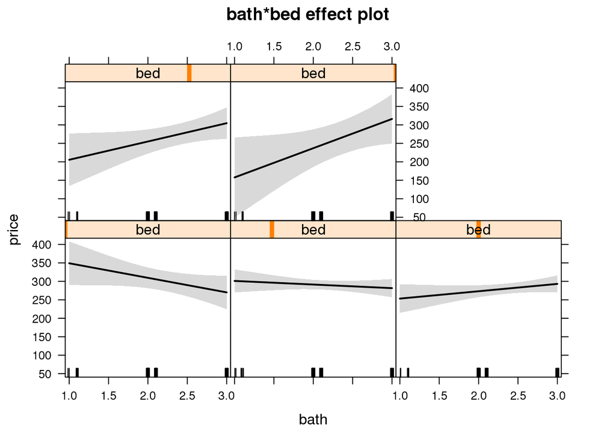

```r
plot(effect("bath*bed", mod2))
```

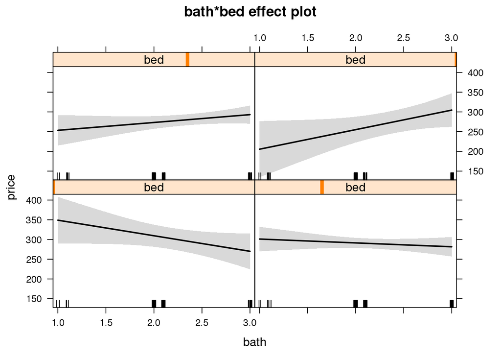

```r
plot(effect("bath*bed", mod2, xlevels=list(bed=2:5)))
```

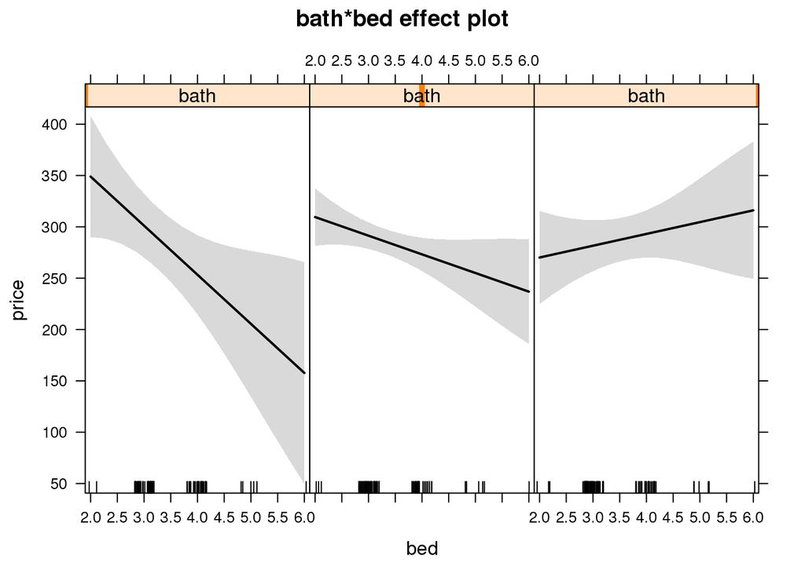

```r
plot(effect("bath*bed", mod2, xlevels=list(bath=1:3)))
```

**Explain what each set of graphs is showing.**

The initial set of graphs show the effects of all the predictors of `mod2` on `price`, with the predictor on the $x$-axis and price on the $y$-axis. This makes intuitive sense - as seen in the graphs, we would expect price to increase as factors like size or lot increase, and decrease as age increases.

The second set of graphs shows the effect of `bed*bath` as a predictor on `price`. Each separate line represents a different number of bedrooms (two through six), with the number of bathrooms on the $x$-axes and price again on the $y$-axes.

The third set of graphs is the same as the second, but eliminates any houses that have six bedrooms.

The fourth set of graphs again shows the effect of `bed*bath` as a predictor on `price`, but is formatted differently. Here each seperate line represents a different number of bathrooms (one through three), while the $x$-axes represent bedrooms.